# Recommendation system for Books

Reagan Kesseku

```r
# set working directory ---------------------
setwd("D:/Ph.D_materials/Programming/R_programming/mdsr/Books-recommendation-systems")
```

```r
# Load functions and packages ---------------------------
source("book_pkg.R")
```

```r
# parallel computing ----------------------
cl = makePSOCKcluster(5)
registerDoParallel(cl)
```

#### Creating Books Recommendation System using Machine Learning algorithm in R

```r
# Import the datasets -------------------
books <- read.csv("BX-Books.csv", header = T, sep = ";")
users <- read.csv("BX-users.csv", header = T, sep = ";")
ratings <- read.csv("BX-Book-Ratings.csv", header = T, sep = ";")
```

```r
# Take a sample look at the book dataset --------------------------------------
books %>%
    sample_n(7) %>%
    datatable(options = list(scrollX = TRUE))
```

|  | ISBN | Book.Title | Book.Author | Year.Of.Publication | Publisher | Image.URL.S | Image.URL.M | Image.URL.L |
| --- | --- | --- | --- | --- | --- | --- | --- | --- |
| 1 | 3453072057 | Vaterland. | Robert Harris | 1994 | Heyne | http://images.amazon.com/images/P/3453072057.01.THUMBZZZ.jpg | http://images.amazon.com/images/P/3453072057.01.MZZZZZZZ.jpg | http://images.amazon.com/images/P/3453072057.01.LZZZZZZZ.jpg |
| 2 | 0812564375 | Mount Dragon: A Novel | Douglas Preston | 1997 | Tor Books | http://images.amazon.com/images/P/0812564375.01.THUMBZZZ.jpg | http://images.amazon.com/images/P/0812564375.01.MZZZZZZZ.jpg | http://images.amazon.com/images/P/0812564375.01.LZZZZZZZ.jpg |
| 3 | 0515108669 | Lone Star in the Timberlands (Lone Star, No 118) | Wesley Ellis | 1992 | Jove Books | http://images.amazon.com/images/P/0515108669.01.THUMBZZZ.jpg | http://images.amazon.com/images/P/0515108669.01.MZZZZZZZ.jpg | http://images.amazon.com/images/P/0515108669.01.LZZZZZZZ.jpg |
| 4 | 0553203533 | Murder at the Red October | Anthony Olcott | 1982 | Bantam Books | http://images.amazon.com/images/P/0553203533.01.THUMBZZZ.jpg | http://images.amazon.com/images/P/0553203533.01.MZZZZZZZ.jpg | http://images.amazon.com/images/P/0553203533.01.LZZZZZZZ.jpg |
| 5 | 0231069170 | School of the Sun (Twentieth-Century Continental Fiction) | Ana Maria Matute | 1989 | Columbia University Press | http://images.amazon.com/images/P/0231069170.01.THUMBZZZ.jpg | http://images.amazon.com/images/P/0231069170.01.MZZZZZZZ.jpg | http://images.amazon.com/images/P/0231069170.01.LZZZZZZZ.jpg |
| 6 | 0862999278 | The Diary of a Nobody | George Grossmith | 1991 | Sutton Pub Ltd | http://images.amazon.com/images/P/0862999278.01.THUMBZZZ.jpg | http://images.amazon.com/images/P/0862999278.01.MZZZZZZZ.jpg | http://images.amazon.com/images/P/0862999278.01.LZZZZZZZ.jpg |
| 7 | 0689859376 | The Seeing Stone (The Spiderwick Chronicles, Book 2) | Tony DiTerlizzi | 2003 | Simon &amp;amp; Schuster Children's Publishing | http://images.amazon.com/images/P/0689859376.01.THUMBZZZ.jpg | http://images.amazon.com/images/P/0689859376.01.MZZZZZZZ.jpg | http://images.amazon.com/images/P/0689859376.01.LZZZZZZZ.jpg |

For the books dataset, there are 115253 observations and 8 variables in the movies data. While the top five (5) column names (ISBN, Book title, Author, Year of publication, publisher) are clear book text or numeric data, the remaining 3 are images.

#### Anyway, in order to generate more realistic data, we will include a new variable called ‘Category’. This variable will indicate if the book belongs to any of the following categories:

Action and Adventure. Classic. Detective and Mystery. Fantasy.

```r
set.seed(123)
categories = c("Action and Adventure", "Classic", "Detective and Mystery", "Fantasy")

books <- books %>%
    mutate(category = sample(categories, n(), replace = TRUE, prob = c(0.25, 0.3,
        0.25, 0.2)) %>%
        as.factor())

rm(categories)
```

```r
books <- books %>%
    mutate(ISBN = paste0("ISBN.", ISBN))
users <- users %>%
    mutate(User.ID = paste0("User.", User.ID))
ratings <- ratings %>%
    mutate(ISBN = paste0("ISBN.", ISBN), User.ID = paste0("User.", User.ID))

books %>%
    sample_n(2) %>%
    datatable(options = list(scrollX = TRUE))
```

|  | ISBN | Book.Title | Book.Author | Year.Of.Publication | Publisher | Image.URL.S | Image.URL.M | Image.URL.L | category |
| --- | --- | --- | --- | --- | --- | --- | --- | --- | --- |
| 1 | ISBN.067974276X | The New Yorker Book of Cat Cartoons/Miniature Edition | New Yorker Magazine | 1992 | Alfred A. Knopf | http://images.amazon.com/images/P/067974276X.01.THUMBZZZ.jpg | http://images.amazon.com/images/P/067974276X.01.MZZZZZZZ.jpg | http://images.amazon.com/images/P/067974276X.01.LZZZZZZZ.jpg | Action and Adventure |
| 2 | ISBN.0385312512 | Midnight Lemonade | Ann Goethe | 1994 | Delta Trade Paperbacks | http://images.amazon.com/images/P/0385312512.01.THUMBZZZ.jpg | http://images.amazon.com/images/P/0385312512.01.MZZZZZZZ.jpg | http://images.amazon.com/images/P/0385312512.01.LZZZZZZZ.jpg | Action and Adventure |

Exploring the rating data On the other hand, we will see how the ratings of the books are distributed. This is very important for the collaborative recommendation systems that we will build with R.

library(ggplot2)

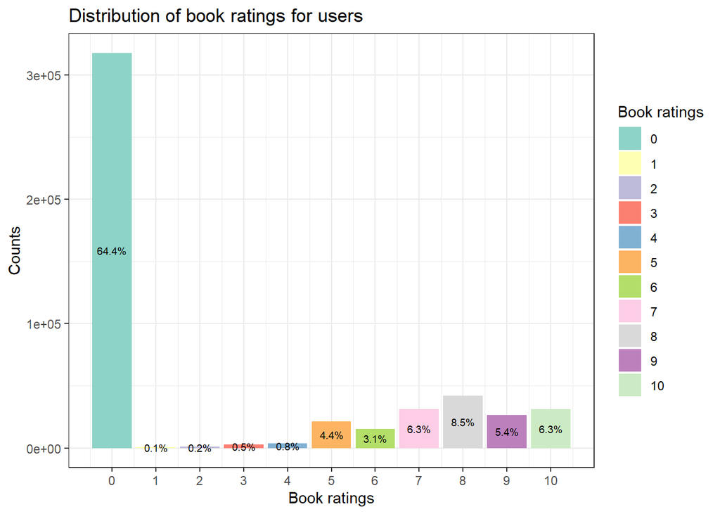

```r
ratings %>%
    group_by(Book.Rating) %>%
    summarize(cases = n()) %>%
    mutate(percentage = cases/sum(cases) * 100) %>%
    ggplot(aes(Book.Rating, cases, fill = factor(Book.Rating))) + geom_col() + geom_text(aes(label = paste0(round(percentage,
    1), "%")), position = position_stack(vjust = 0.5), color = "black", size = 2.5) +
    scale_fill_brewer(palette = "Set3") + theme_bw() + labs(x = "Book ratings", y = "Counts",
    fill = "Book ratings", title = "Distribution of book ratings for users") + scale_x_continuous(breaks = 0:10)
```

It is apparent that there are several zeros. This is not surprising as most people read books without rating them. Thus, we will filter the complete ratings cases.

```r
# filter non zero ratings ------------------------
ratings <- ratings %>%
    filter(Book.Rating != 0)

ratings %>%
    dim()  # new dimension
```

```
## [1] 176019      3
```

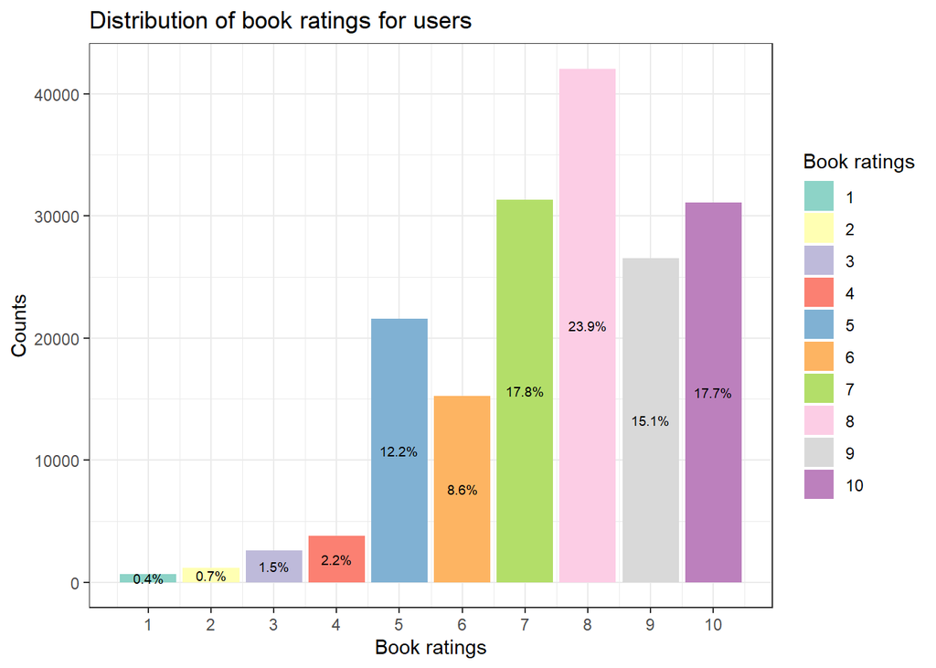

```r
# Resulting distribution after filtering --------------------------------------
ratings %>%
    group_by(Book.Rating) %>%
    summarize(cases = n()) %>%
    mutate(percentage = cases/sum(cases) * 100) %>%
    ggplot(aes(Book.Rating, cases, fill = factor(Book.Rating))) + geom_col() + geom_text(aes(label = paste0(round(percentage,
    1), "%")), position = position_stack(vjust = 0.5), color = "black", size = 2.5) +
    scale_fill_brewer(palette = "Set3") + theme_bw() + labs(x = "Book ratings", y = "Counts",
    fill = "Book ratings", title = "Distribution of book ratings for users") + scale_x_continuous(breaks = 0:10)
```

The change in percentages as displayed is a result of the total sample changing after filtering the complete cases.

Finally, let’s see how much each person scores:

```r
# Users score
users_rate <- ratings %>%
    group_by(User.ID) %>%
    count()

# provide summary measures
favstats(~n, data = users_rate)
```

```
##  min Q1 median Q3  max mean   sd     n missing
##    1  1      1  3 1906 5.32 23.4 33095       0
```

As we can see, 75% of users have given 3 recommendations or less. We are going to remove these people to keep only more significant users and, thus, reduce computing needs:

```r
user_index <- users_rate %>%
    filter(n > 4) %>%
    pull(User.ID)

users <- users %>%
    filter(User.ID %in% user_index)
ratings <- ratings %>%
    filter(User.ID %in% user_index)
books <- books %>%
    filter(ISBN %in% ratings$ISBN)
```

#### Content based Recommendation system

```r
# parallelized computing ---------------------- cl = makePSOCKcluster(5)
# registerDoParallel(cl)

# Taking a subset of the data
book_feature <- books %>%
    select(Book.Author, Publisher, category) %>%
    slice(1:10000)

# convert to factors
book_feature <- book_feature %>%
    mutate(across(c(1, 2, 3), as.factor))

dissimilarity <- book_feature %>%
    daisy(metric = "gower", weights = c(2, 0.5, 1)) %>%
    as.matrix()

row.names(dissimilarity) <- books$ISBN[1:10000]
colnames(dissimilarity) <- books$ISBN[1:10000]

datatable(dissimilarity[15:20, 15:20])
```

|  | ISBN.0971880107 | ISBN.0345402871 | ISBN.0345417623 | ISBN.0684823802 | ISBN.0375759778 | ISBN.0375406328 |
| --- | --- | --- | --- | --- | --- | --- |
| ISBN.0971880107 | 0 | 1 | 1 | 1 | 1 | 1 |
| ISBN.0345402871 | 1 | 0 | 0.857142857142857 | 1 | 1 | 0.714285714285714 |
| ISBN.0345417623 | 1 | 0.857142857142857 | 0 | 0.714285714285714 | 1 | 1 |
| ISBN.0684823802 | 1 | 1 | 0.714285714285714 | 0 | 1 | 1 |
| ISBN.0375759778 | 1 | 1 | 1 | 1 | 0 | 1 |
| ISBN.0375406328 | 1 | 0.714285714285714 | 1 | 1 | 1 | 0 |

Anyway, we are going to choose a user and keep the books they have read. We will apply the algorithm on these books:

```r
user_id = "User.1167"

user_books = ratings %>%
    filter(User.ID == user_id & ISBN %in% books$ISBN[1:10000]) %>%
    arrange(desc(Book.Rating))

head(user_books, 10)
```

```
##     User.ID            ISBN Book.Rating
## 1 User.1167 ISBN.0060929596          10
## 2 User.1167 ISBN.0802135196           9
## 3 User.1167 ISBN.0440224675           8
## 4 User.1167 ISBN.0679450548           7
## 5 User.1167 ISBN.0743230213           7
## 6 User.1167 ISBN.0373834985           5
## 7 User.1167 ISBN.038533656X           5
## 8 User.1167 ISBN.0440217520           5
```

```r
books$ISBN = as.character(books$ISBN)
selected_books = user_books[, c("ISBN", "Book.Rating")]

recomendar = function(selected_books, dissimilarity_matrix, books, n_recommendations = 5) {

    selected_book_indexes = which(colnames(dissimilarity_matrix) %in% selected_books$ISBN)

    results = data.frame(dissimilarity_matrix[, selected_book_indexes], recommended_book = row.names(dissimilarity_matrix),
        stringsAsFactors = FALSE)

    recomendaciones = results %>%
        pivot_longer(cols = c(-"recommended_book"), names_to = "read_book", values_to = "dissimilarity") %>%
        left_join(selected_books, by = c(recommended_book = "ISBN")) %>%
        arrange(desc(dissimilarity)) %>%
        filter(recommended_book != read_book) %>%
        filter(!is.na(Book.Rating)) %>%
        mutate(similarity = 1 - dissimilarity, weighted_score = similarity * Book.Rating) %>%
        arrange(desc(weighted_score)) %>%
        filter(weighted_score > 0) %>%
        group_by(recommended_book) %>%
        slice(1) %>%
        top_n(n_recommendations, weighted_score) %>%
        left_join(books, by = c(recommended_book = "ISBN"))

    return(recomendaciones)
}

recomendaciones = recomendar(selected_books, dissimilarity, books)
datatable(recomendaciones, options = list(scrollX = TRUE))
```

|  | recommended_book | read_book | dissimilarity | Book.Rating | similarity | weighted_score | Book.Title | Book.Author | Year.Of.Publication | Publisher | Image.URL.S | Image.URL.M | Image.URL.L | category |
| --- | --- | --- | --- | --- | --- | --- | --- | --- | --- | --- | --- | --- | --- | --- |
| 1 | ISBN.0060929596 | ISBN.0743230213 | 0.714285714285714 | 10 | 0.285714285714286 | 2.85714285714286 | As Nature Made Him : The Boy Who Was Raised as a Girl | John Colapinto | 2001 | Perennial | http://images.amazon.com/images/P/0060929596.01.THUMBZZZ.jpg | http://images.amazon.com/images/P/0060929596.01.MZZZZZZZ.jpg | http://images.amazon.com/images/P/0060929596.01.LZZZZZZZ.jpg | Classic |
| 2 | ISBN.0373834985 | ISBN.0743230213 | 0.714285714285714 | 5 | 0.285714285714286 | 1.42857142857143 | Comfortable Wife | Stephanie Laurens | 2002 | Harlequin | http://images.amazon.com/images/P/0373834985.01.THUMBZZZ.jpg | http://images.amazon.com/images/P/0373834985.01.MZZZZZZZ.jpg | http://images.amazon.com/images/P/0373834985.01.LZZZZZZZ.jpg | Classic |
| 3 | ISBN.038533656X | ISBN.0440217520 | 0.714285714285714 | 5 | 0.285714285714286 | 1.42857142857143 | Apocalipstick | SUE MARGOLIS | 2003 | Delta | http://images.amazon.com/images/P/038533656X.01.THUMBZZZ.jpg | http://images.amazon.com/images/P/038533656X.01.MZZZZZZZ.jpg | http://images.amazon.com/images/P/038533656X.01.LZZZZZZZ.jpg | Fantasy |
| 4 | ISBN.0440217520 | ISBN.038533656X | 0.714285714285714 | 5 | 0.285714285714286 | 1.42857142857143 | Tunnel Vision (V.I. Warshawski Novels (Paperback)) | Sara Paretsky | 1995 | Dell | http://images.amazon.com/images/P/0440217520.01.THUMBZZZ.jpg | http://images.amazon.com/images/P/0440217520.01.MZZZZZZZ.jpg | http://images.amazon.com/images/P/0440217520.01.LZZZZZZZ.jpg | Fantasy |
| 5 | ISBN.0679450548 | ISBN.038533656X | 0.714285714285714 | 7 | 0.285714285714286 | 2 | I Was Amelia Earhart | Jane Mendelsohn | 1996 | Random House Inc | http://images.amazon.com/images/P/0679450548.01.THUMBZZZ.jpg | http://images.amazon.com/images/P/0679450548.01.MZZZZZZZ.jpg | http://images.amazon.com/images/P/0679450548.01.LZZZZZZZ.jpg | Fantasy |
| 6 | ISBN.0743230213 | ISBN.0802135196 | 0.714285714285714 | 7 | 0.285714285714286 | 2 | Harem: A Novel | Dora Levy Mossanen | 2002 | Touchstone | http://images.amazon.com/images/P/0743230213.01.THUMBZZZ.jpg | http://images.amazon.com/images/P/0743230213.01.MZZZZZZZ.jpg | http://images.amazon.com/images/P/0743230213.01.LZZZZZZZ.jpg | Classic |
| 7 | ISBN.0802135196 | ISBN.0743230213 | 0.714285714285714 | 9 | 0.285714285714286 | 2.57142857142857 | Valley of the Dolls: A Novel | Jacqueline Susann | 1997 | Grove Press | http://images.amazon.com/images/P/0802135196.01.THUMBZZZ.jpg | http://images.amazon.com/images/P/0802135196.01.MZZZZZZZ.jpg | http://images.amazon.com/images/P/0802135196.01.LZZZZZZZ.jpg | Classic |

```r
# # Create a directory to save the images dir <- 'image_directory'
# dir.create(dir, showWarnings = FALSE) # Data with URLs data <-
# read.table(text = 'recommended_book\tImage.URL.M
# ISBN.0060929596\thttp://images.amazon.com/images/P/0060929596.01.MZZZZZZZ.jpg
# ISBN.0373834985\thttp://images.amazon.com/images/P/0373834985.01.MZZZZZZZ.jpg
# ISBN.038533656X\thttp://images.amazon.com/images/P/038533656X.01.MZZZZZZZ.jpg
# ISBN.0440217520\thttp://images.amazon.com/images/P/0440217520.01.MZZZZZZZ.jpg
# ISBN.0679450548\thttp://images.amazon.com/images/P/0679450548.01.MZZZZZZZ.jpg
# ISBN.0743230213\thttp://images.amazon.com/images/P/0743230213.01.MZZZZZZZ.jpg
# ISBN.0802135196\thttp://images.amazon.com/images/P/0802135196.01.MZZZZZZZ.jpg',
# header = TRUE, stringsAsFactors = FALSE) # For loop to download image for (i
# in 1:nrow(data)) { url <- data[i, 'Image.URL.M'] filename <- paste0(dir, '/',
# basename(url)) download.file(url, filename, mode = 'wb') cat('Downloaded
# image', i, 'out of', nrow(data), '\n') } # Confirm the number of downloaded
# images num_images <- length(list.files(dir)) cat('Downloaded', num_images,
# 'images.\n')
```

```r
# visualizar_recomendacion = function(recomendation, recommended_book, image,
# n_books = 5){ if(n_books > nrow(recomendation)) {n_books =
# nrow(recomendation)} plot = list() if
# (!dir.exists('content_recommended_images')) {
# dir.create('content_recommended_images') } for(i in 1:n_books){ # Create dir
# & Download the images img = pull(recomendation[i, colnames(recomendation) ==
# image]) name = paste0('content_recommended_images/',i,'.jpg')
# suppressMessages( download.file(as.character(img), destfile = name ,mode =
# 'w') ) download.file() # Assign Objetc plot[[i]] = rasterGrob(readJPEG(name))
# } do.call(marrangeGrob, args = list(plot, ncol = n_books, nrow = 1, top=''))
# } visualizar_recomendacion(recomendaciones, 'recommended_book',
# 'Image.URL.M')
```